# Case Study: Welcome to University

datING - BDA 503 - Fall 2017

### **Introduction**

In this case study our group are going to explore university entrance examinations (YGS/LYS) data from 2017.

Dataset consists of undergraduate programs offered in 2017. Each program offers an availability (i.e. quota). Then students get placed according to their lists and their scores. Each program is filled with the students ranked by their scores until placements are equal to availability. Student placed to a a program with the highest score forms the maximum score of that program and the last student to be placed forms the minimum score.

MEF University management asks us to examine the data and provide insights that are useful to understand MEF University’s place among its competitors and in the undergraduate market. We decided to examine occupancy rate of quota which is found dividing the general placement into general quota. After assessment the university with analysis, we wil have an outcome and wil offer a suggestion to university management.

#### *Clean Data and Assign New Population*

- First we had a quick review of number of rows and columns “osym_data_2017” dataset.

```r
dim(osym_data_2017)
```

```
## [1] 11031    14
```

- We filtered abroad universities that university management is not interested. (IDs that start with 3 or 4)

```r
#Filtered abroad university
osym_data_2017_except_abroad <- osym_data_2017 %>%
  filter(program_id<300000000)
```

- Let’s see number of our new population excluding the abroad universities.

```r
dim(osym_data_2017_except_abroad)
```

```
## [1] 9812   14
```

### **Analysis**

- We found the occupancy rates of quota in all the universities.

```r
Occupancy_rate_of_quota <- osym_data_2017_except_abroad  %>%
  group_by(university_name) %>%
  summarise(total_quota = sum(as.integer(general_quota)  ),
            total_placement = sum(as.integer(general_placement) ),
            Percentage=round((sum(as.integer(general_placement) )/sum(as.integer(general_quota) ))*100)) %>%
  arrange(Percentage)

Occupancy_rate_of_quota
```

```
## # A tibble: 172 x 4
##                            university_name total_quota total_placement Percentage
##                                      <chr>       <int>           <int>      <dbl>
##  1                    ANADOLU ÜNİVERSİTESİ       55767           12864         23
##  2            İSTANBUL RUMELİ ÜNİVERSİTESİ         528             197         37
##  3 ALANYA HAMDULLAH EMİN PAŞA ÜNİVERSİTESİ         155              60         39
##  4                   ALTINBAŞ ÜNİVERSİTESİ        1749             770         44
##  5                    İSTİNYE ÜNİVERSİTESİ         953             429         45
##  6           TÜRK HAVA KURUMU ÜNİVERSİTESİ         596             270         45
##  7               ANTALYA AKEV ÜNİVERSİTESİ         230             125         54
##  8                      TOROS ÜNİVERSİTESİ         510             289         57
##  9                    AVRASYA ÜNİVERSİTESİ        1366             796         58
## 10                    ARDAHAN ÜNİVERSİTESİ        1130             664         59
## # ... with 162 more rows
```

- We found the occupancy rates of quota universities in İstanbul.

```r
Istanbul_Occupancy_rate_of_quota <- osym_data_2017_except_abroad  %>%
  filter(city == "İSTANBUL")%>%
  group_by(university_name) %>%
  summarise(total_quota = sum(as.integer(general_quota)),
            total_placement = sum(as.integer(general_placement)),
            Percentage=round((sum(as.integer(general_placement))/sum(as.integer(general_quota)))*100)) %>%
  arrange(Percentage)

Istanbul_Occupancy_rate_of_quota
```

```
## # A tibble: 51 x 4
##                  university_name total_quota total_placement Percentage
##                            <chr>       <int>           <int>      <dbl>
##  1  İSTANBUL RUMELİ ÜNİVERSİTESİ         528             197         37
##  2         ALTINBAŞ ÜNİVERSİTESİ        1749             770         44
##  3          İSTİNYE ÜNİVERSİTESİ         953             429         45
##  4 İSTANBUL GELİŞİM ÜNİVERSİTESİ        3950            2351         60
##  5   İSTANBUL GEDİK ÜNİVERSİTESİ         690             421         61
##  6    İSTANBUL KENT ÜNİVERSİTESİ         440             269         61
##  7            HALİÇ ÜNİVERSİTESİ        1403             886         63
##  8    İSTANBUL AREL ÜNİVERSİTESİ        1545             980         63
##  9             OKAN ÜNİVERSİTESİ        2393            1555         65
## 10           BİRUNİ ÜNİVERSİTESİ        1077             759         70
## # ... with 41 more rows
```

- Let’s visualize the occupancy rates of quota universities in İstanbul.

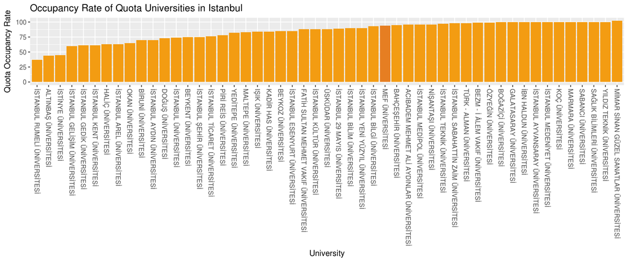

```r
ggplot(Istanbul_Occupancy_rate_of_quota, aes(x=reorder(university_name,Percentage), y=Percentage)) +
  geom_bar(stat = "identity", aes(fill=Istanbul_Occupancy_rate_of_quota$university_name=='MEF ÜNİVERSİTESİ')) +
  labs(title="Occupancy Rate of Quota Universities in Istanbul",x="University",y="Quota Occupancy Rate",fill="") +
  theme (axis.text.x=element_text (angle=-90,vjust=0.5, hjust=0)) +
  scale_fill_manual(values = c('#f39c12', '#e67e22'),guide=FALSE)
```

- Then we found the occupancy rates of quota of MEF University to compare with all universities and İstanbul located universities.

```r
MEF_Occupancy_rate_of_quota <- osym_data_2017_except_abroad  %>%
  filter(university_name == "MEF ÜNİVERSİTESİ")%>%
  group_by(faculty_name) %>%
  summarise(total_quota = sum(as.integer(general_quota)),
            total_placement = sum(as.integer(general_placement)),
            Percentage=round((sum(as.integer(general_placement))/sum(as.integer(general_quota)))*100)) %>%
  arrange(Percentage)

MEF_Occupancy_rate_of_quota
```

```
## # A tibble: 6 x 4
##                                   faculty_name total_quota total_placement Percentage
##                                          <chr>       <int>           <int>      <dbl>
## 1                             Eğitim Fakültesi         130              95         73
## 2 İktisadi, İdari ve Sosyal Bilimler Fakültesi         190             176         93
## 3                              Hukuk Fakültesi         153             153        100
## 4                 Hukuk Fakültesi (Tam Burslu)          17              17        100
## 5                        Mühendislik Fakültesi         212             212        100
## 6         Sanat, Tasarım ve Mimarlık Fakültesi         115             115        100
```

- Let’s visualize the occupancy rates of quota of MEF University with respect to faculty.

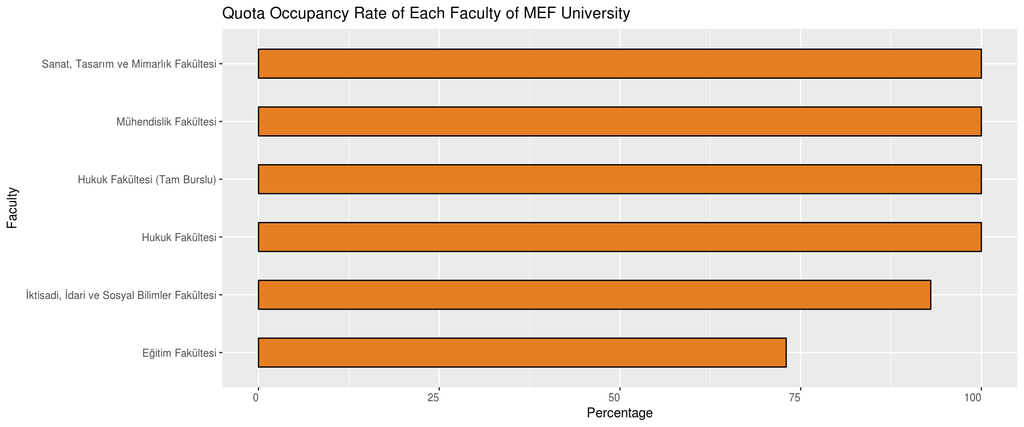

```r
ggplot(MEF_Occupancy_rate_of_quota, aes(x=reorder(faculty_name,Percentage),y=Percentage)) +
  geom_bar(stat = "identity",colour="black", fill="#e67e22", width=.5,) +
  labs(title="Quota Occupancy Rate of Each Faculty of MEF University",x="Faculty",y="Percentage",fill="") +
  theme (axis.text.x=element_text(angle=0,vjust=1, hjust=1)) +
  coord_flip()
```

- Means of occupancy rates of quota.

```r
All_universities_mean<-round(mean(Occupancy_rate_of_quota$Percentage))
İstanbul_universities_mean<-round(mean(Istanbul_Occupancy_rate_of_quota$Percentage))

MEF_Rate<- Istanbul_Occupancy_rate_of_quota  %>%
  select(university_name, Percentage) %>%
  filter(university_name == "MEF ÜNİVERSİTESİ")
```

- We arranged the means and visualize to compare the occupancy rates of quota.

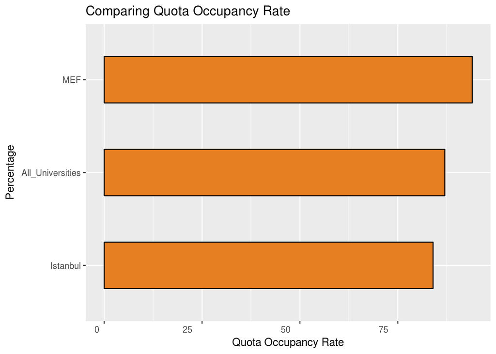

```r
Percentages=data.frame(name=c("All_Universities", "Istanbul","MEF") ,  value=c(All_universities_mean,İstanbul_universities_mean,MEF_Rate$Percentage))

ggplot(Percentages, aes(x=reorder(name,value), y=value)) +
  geom_bar(stat = "identity",colour="black", fill="#e67e22", width=.5,)+
  labs(title="Comparing Quota Occupancy Rate",x="Percentage",y="Quota Occupancy Rate",fill="") +
  theme (axis.text.x=element_text(angle=0,vjust=2, hjust=2)) +
  coord_flip()
```

- As a result, we saw that 3 programs are mentioned below in MEF University have below according its quota.

```r
MEF_Program_Rate <- osym_data_2017_except_abroad  %>%
  filter(university_name == "MEF ÜNİVERSİTESİ")%>%
  group_by(program_name) %>%
  summarise(total_quota = sum(as.integer(general_quota)),
            total_placement = sum(as.integer(general_placement)),
            Percentage=round((sum(as.integer(general_placement))/sum(as.integer(general_quota)))*100)) %>%
  filter(Percentage < 100)

MEF_Program_Rate
```

```
## # A tibble: 3 x 4
##                                                   program_name total_quota total_placement Percentage
##                                                          <chr>       <int>           <int>      <dbl>
## 1                             Ekonomi (İngilizce) (%50 Burslu)          22              10         45
## 2                             İşletme (İngilizce) (%50 Burslu)          22              20         91
## 3 Rehberlik ve Psikolojik Danışmanlık (İngilizce) (%50 Burslu)          60              25         42
```

### **Conclusion**

According to the universites’ occupancy rates of quota, MEF University has 3 program which is not full quota. On the other hand, occupancy rates of quota is higher than universities in Turkey /İstanbul. We suggest an offer to MEF University Management to decrease the quota of 3 non-full programs.